# Summary of TF-MoDISco motifs

Melanie (1028-02098-001-001)

January 07, 2022

# Introduction

# Computational Setup

```r
#Standard packages
library(rtracklayer) ; library(GenomicRanges); library(magrittr) ; library(Biostrings)
library(ggplot2) ; library(reshape2); library(plyranges); library(Rsamtools)
library(dplyr); library(data.table); library(patchwork); library(readr); library(testit)

#KNITR Options
setwd("/n/projects/mw2098/publications/2022_maven_ISL1/analysis/")
options(knitr.figure_dir="../figures/4_motif_summary", java.parameters = "- Xmx6g")

#Lab sources
source("../scripts/granges_common.r")
source("../scripts/metapeak_common.r")
source("../scripts/knitr_common.r")
source("../scripts/caching.r")
source("../scripts/metapeak_functions.R")

#Specific sources
library(BSgenome.Hsapiens.UCSC.hg19)
library(ggpubr)
library(rhdf5)
library(ggseqlogo)
source("../scripts/motif_functions.r")
source("scripts/variables.r")

#Pre-existing variables
modisco_dir <- '../modisco/seq_width1000-lr0.001-lambda100-n_dil_layers9-conv_kernel_size7-tconv_kernel_size7-filters64/'
motifs.path<-'tsv/mapped_motifs/all_instances_curated_1based.tsv.gz'
tasks <- c('I_WT_D6CM','I_WT_S3MN')
```

# Import motifs of interest

```r
motifs.gr<-readr::read_tsv(motifs.path) %>%
  GenomicRanges::makeGRangesFromDataFrame(keep.extra.columns = T, starts.in.df.are.0based = F)
```

# Extract information for metaplot

## Function for extraction

- Inputs:
  - motif_name: string naming motif to filter `motifs.gr` from
  - motifs.gr: GRanges object with `motif_name` pattern as a `pattern_name` column
  - motif_logo_h5_path: path to .h5 object that is compatible with code to extract logos at `/n/projects/mw2098/shared_code/bpnet/bpnet_extract_modisco_logos.py`
  - footprint_window: window width to extract metapeaks around [default = 400]
- Output: list of following elements:
  - motif_name: motif
  - motif_count: number of motifs mapped using CWM scanning
  - actual_metapeaks.df: df of metapeak of averaged motifs
  - contrib_averages.df: df of metapeak of averaged contribution across motifs
  - ppm.mat: motif PPM
  - cwm.mat: motif CWM

```r
extract_metaplot_information<-function(motif_name, motifs.gr, motif_logo_h5_path, footprint_window = 400, threads = 6){
  library(rhdf5)

  motif.gr<-motifs.gr %>% plyranges::filter(pattern_name==motif_name)

  #Extract average task contribution
  contrib_averages.df<-lapply(contrib.profile.bws, function(x){
    regionMeans(regions = motif.gr, cvg = x) %>% mean(., na.rm = T)
  }) %>% as.data.frame() %>% data.table() %>%
    melt.data.table(variable.name = 'task_name', value.name = 'contrib') %>%
    dplyr::mutate(motif = motif_name)

  #Extract average task profiles
  actual_metapeaks.df<-mclapply(names(actual.norm.bws), function(x){
    mp.df<-standard_metapeak(gr = motif.gr %>% resize(1, "center"), sample = actual.norm.bws[[x]],
                        upstream = floor(footprint_window/2), downstream = ceiling(footprint_window/2), smooth = 10) %>%
      dplyr::mutate(task_name = x)
  }, mc.cores = threads) %>% rbindlist() %>% dplyr::mutate(motif = motif_name)

  #Extract PPMs and CWMs
  testit::assert('This motif set has varying pattern identifiers.', (motif.gr$pattern %>% unique %>% length)==1)
  testit::assert('This motif set has varying modisco tasks.', (motif.gr$modisco_task %>% unique %>% length)==1)

  ppm.mat<-rhdf5::h5read(motif_logo_h5_path, paste0('/', motif.gr$pattern[1], '/PPM/trimmed'))
  cwm.mat<-rhdf5::h5read(motif_logo_h5_path, paste0('/', motif.gr$pattern[1], '/CWM/trimmed/', motif.gr$modisco_task[1]))

  return(list(motif_name = motif_name, motif_count = length(motif.gr),
              contrib_averages.df = contrib_averages.df,
              actual_metapeaks.df = actual_metapeaks.df,
              ppm.mat = ppm.mat, cwm.mat = cwm.mat))

}
```

## Extract information from relevant .bw files and .h5 files.

```r
metaplot.list<-mclapply(motifs.gr$pattern_name %>% unique, function(x){
  message(x)
  motif.gr<-motifs.gr %>% plyranges::filter(pattern_name==x)
  info.list<-extract_metaplot_information(motif_name = x, motifs.gr = motifs.gr,
                                          motif_logo_h5_path = paste(modisco_dir, motif.gr$modisco_task[1], '_profile/modisco_logos.h5', sep = ''),
                                          footprint_window = 2000)

}, mc.cores = 8)
names(metaplot.list)<-motifs.gr$pattern_name %>% unique
saveRDS(metaplot.list, '../tmp/curated_motif_metaplot_information.list.rds')
```

## Organize across different categories.

```r
metaplot.list<-readRDS('../tmp/curated_motif_metaplot_information.list.rds')
```

Here, in order to properly categorize the PWMs in terms of entropy, we will extract count frequency information directly.

```r
seq.list<-lapply(names(metaplot.list), function(x){
  message(x)
  motif.gr<-motifs.gr %>% plyranges::filter(pattern_name==x)
  seqlet.gr<-rtracklayer::import(paste0(modisco_dir, '/', motif.gr$modisco_task[1], '_profile/seqlets/', motif.gr$pattern[1], '.bed.gz'))
  seqlet.seq<-getSeq(BSgenome.Hsapiens.UCSC.hg19, seqlet.gr, as.character = T)
})
names(seq.list)<-names(metaplot.list)

#Collect other information
cwm.list<-lapply(metaplot.list, function(x) {
  mat<-x$cwm.mat
  rownames(mat)<-c('A','C','G','T')
  return(mat)
})

metapeaks.df<-lapply(metaplot.list, function(x) x$actual_metapeaks.df) %>% rbindlist
contribs.df<-lapply(metaplot.list, function(x) x$contrib_averages.df) %>% rbindlist
labels.df<-lapply(metaplot.list, function(x) data.frame(motif_name = x$motif_name, motif_count = x$motif_count)) %>% rbindlist
```

# Plot metaplot

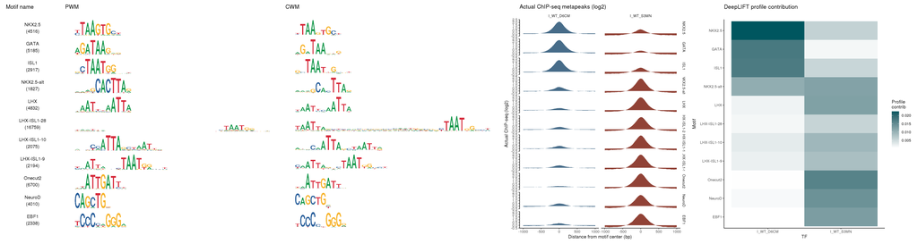

```r
motif_order<-c('NKX2.5', 'GATA', 'ISL1', 'NKX2.5-alt',
               'LHX', 'LHX-ISL1-28', 'LHX-ISL1-10', 'LHX-ISL1-9','Onecut2',
               'NeuroD', 'EBF1')
tf_order<-c('I_WT_D6CM','I_WT_S3MN')

labels.df$motif_name<-factor(labels.df$motif_name, levels = motif_order)
label.plot<-ggplot(labels.df)+
  geom_text(aes(x= .5, y = .5, label = paste0(motif_name, '\n(', motif_count, ')')))+
  facet_grid(motif_name~.)+
  ggtitle('Motif name')+
  theme_classic()+theme(axis.line = element_blank(), axis.text = element_blank(), axis.ticks = element_blank(), axis.title = element_blank(),
                        strip.background = element_blank(), strip.text = element_blank())

seq.list<-lapply(motif_order, function(x) seq.list[[x]])
pwm.plot<-ggplot() + geom_logo(seq.list) +
  facet_grid(seq_group~., scales = 'fixed') +
  theme_classic()+
  ggtitle('PWM')+
  theme(axis.line = element_blank(), axis.text = element_blank(), axis.ticks = element_blank(), axis.title = element_blank(),
        strip.background = element_blank(), strip.text = element_blank())

cwm.list<-lapply(motif_order, function(x) cwm.list[[x]])
cwm.plot<-ggplot() + geom_logo(cwm.list, method='custom', seq_type='dna') +
  facet_grid(seq_group~., scales = 'free_y')+
  theme_classic()+
  ggtitle('CWM')+
  theme(axis.line = element_blank(), axis.text = element_blank(), axis.ticks = element_blank(), axis.title = element_blank(),
        strip.background = element_blank(), strip.text = element_blank())

metapeaks.df$task_name<-factor(metapeaks.df$task_name, levels = tf_order)
metapeaks.df$motif<-factor(metapeaks.df$motif, levels = motif_order)
mp.plot<-ggplot(metapeaks.df, aes(x = tss_distance, y = reads, fill = task_name))+
  geom_area()+
  scale_fill_manual(values = color.vec[tf_order], name = 'task')+
  scale_x_continuous(name = 'Distance from motif center (bp)', breaks = seq(-1000, 1000, 500))+
  scale_y_continuous(name = 'Actual ChIP-seq (log2)')+
  facet_grid(motif ~ task_name, scales = 'fixed')+
  ggtitle('Actual ChIP-seq metapeaks (log2)')+
  theme_classic()+
  theme(legend.position = 'none', strip.background = element_blank())

contribs.df$task_name<-factor(contribs.df$task_name, levels = tf_order)
contribs.df$motif<-factor(contribs.df$motif, levels = rev(motif_order))
contrib.plot<-ggplot(contribs.df, aes(x = task_name, y = motif, fill = contrib))+
  geom_tile()+
  scale_fill_gradient(low = 'white', high = '#00565f', name = 'Profile\ncontrib')+
  scale_x_discrete(name = 'TF')+
  scale_y_discrete(name = 'Motif')+
  ggtitle('DeepLIFT profile contribution')+
  theme_classic()+
  theme()

g<-label.plot + pwm.plot + cwm.plot + mp.plot + contrib.plot + patchwork::plot_layout(nrow = 1, widths = c(.1, .4, .4, .3, .3))
g
```

```r
ggsave('../figures/4_motif_summary/figure2D-curated_motif_metaplot.png', g, height = 12, width = 30)
ggsave('../figures/4_motif_summary/figure2D-curated_motif_metaplot.pdf', g, height = 12, width = 30)
```

In conclusion, you can see good binding to each motif as well as localized contribution validating the motif choices.